# Welcome to Jingyu Ma's game analysis ,this analysis is based on [a Steam game data that includes all the games published on Steam upto 2025 May.](https://www.kaggle.com/datasets/fronkongames/steam-gam

## 7. ⭐ Comprehensive Evaluation System

- Professional vs. user score comparison
  - Critical acclaim but commercial failure game identification
- Multi-dimensional game rating model
  - Comprehensive evaluation metrics

```
Top 10 Games by Comprehensive Rating:
```

|  | name | comprehensive_rating | popularity_score | quality_score | engagement_score | content_score | accessibility_score | value_score |
| --- | --- | --- | --- | --- | --- | --- | --- | --- |
| 17585 | Dota 2 | 58.662884 | 0.817612 | 0.706087 | 0.141126 | 0.340553 | 1.000000 | 0.527915 |
| 46158 | Counter-Strike: Global Offensive | 55.056884 | 0.678900 | 0.677874 | 0.141604 | 0.394972 | 1.000000 | 0.476177 |
| 30583 | Team Fortress 2 | 53.224707 | 0.590672 | 0.749610 | 0.082679 | 0.431998 | 1.000000 | 0.316825 |
| 28170 | Portal 2 | 50.113972 | 0.435591 | 0.768550 | 0.122483 | 0.506049 | 0.997003 | 0.000007 |
| 39530 | Left 4 Dead 2 | 49.153470 | 0.476582 | 0.730880 | 0.061660 | 0.517572 | 0.997003 | 0.000017 |
| 36775 | Half-Life 2 | 47.600072 | 0.430057 | 0.771460 | 0.108166 | 0.361918 | 0.997003 | 0.000005 |
| 60445 | Stardew Valley | 47.310638 | 0.438644 | 0.731032 | 0.102071 | 0.404813 | 0.995503 | 0.000019 |
| 4314 | BattleBlock Theater® | 47.235518 | 0.397066 | 0.704871 | 0.112954 | 0.498199 | 0.995503 | 0.000002 |
| 46416 | Terraria | 46.820388 | 0.477436 | 0.695792 | 0.086861 | 0.385478 | 0.997003 | 0.000052 |
| 21736 | Divinity: Original Sin 2 - Definitive Edition | 46.701524 | 0.393974 | 0.751846 | 0.121278 | 0.473248 | 0.853169 | 0.000007 |

```
    === Game Performance Analysis: Grand Theft Auto V ===
    Comprehensive Rating: 44.79/100
    Rank: #86

    Dimension Analysis:
    📊 Popularity: 44.5%
       - Player Base: 20000000.0
       - Positive Rating: 84.8%
       - Peak Concurrent Users: 170,527

    🎯 Game Quality: 74.7%
       - Metacritic Score: 96/100
       - Achievements Count: 77

    ⏱️ Player Engagement: 14.3%
       - Average Playtime: 13,650 minutes
       - Recent Activity: 656 minutes

    🎮 Content Richness: 36.6%
       - DLC Count: 1
       - Supported Languages: 13 languages
       - Game Categories: 11 categories

    🔧 Accessibility: 49.0%
       - Supported Platforms: 1
       - Age Requirement: 17+
       - Price: $0.00
```

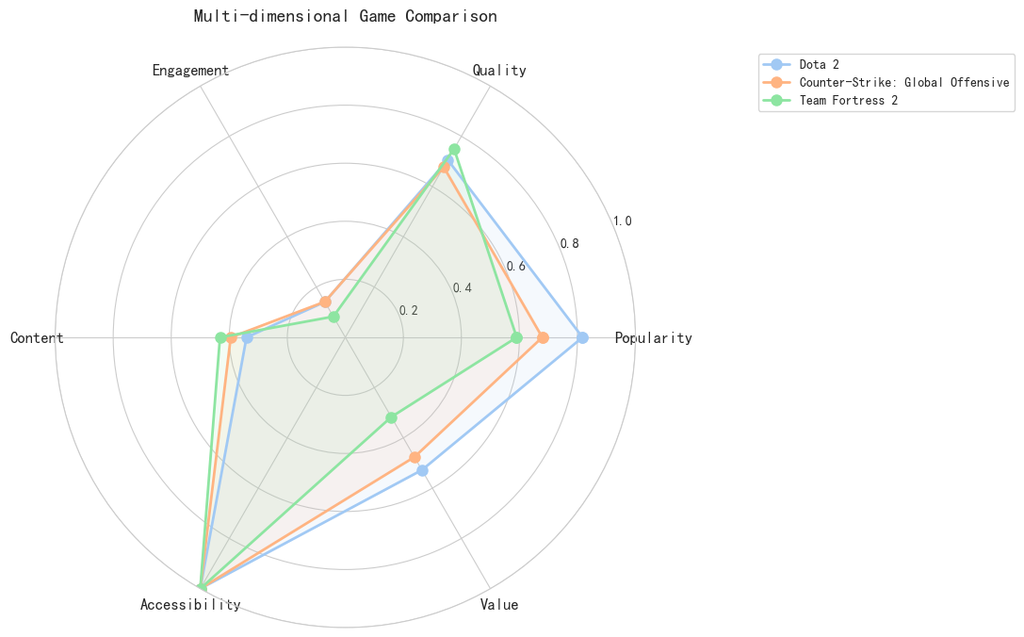

```python
import pandas as pd
import numpy as np
from sklearn.preprocessing import MinMaxScaler
import ast
import math
from scipy import stats
import matplotlib.pyplot as plt
import seaborn as sns

class GameRatingModel:
    def __init__(self):
        # 定义各维度权重 (移除了开发商声誉，相应调整权重)
        self.weights = {
            'popularity': 0.25,      # 流行度
            'quality': 0.25,         # 游戏质量
            'engagement': 0.20,      # 玩家参与度
            'content': 0.15,         # 内容丰富度
            'accessibility': 0.10,   # 可访问性
            'value': 0.05           # 价值评估
        }

    def calculate_popularity_metrics(self, df):
        """计算流行度维度得分"""
        metrics = {}

        # 玩家基数 (标准化)
        df['owner_min'] = df['estimated_owners'].str.extract(r'(\d+)')[0].astype(float)
        metrics['owner_score'] = self.normalize_score(df['owner_min'])

        # 评价比例
        df['total_votes'] = df['positive'] + df['negative']
        df['positive_ratio'] = df['positive'] / df['total_votes'].replace(0, 1)
        metrics['approval_score'] = df['positive_ratio']

        # 并发用户峰值
        metrics['concurrency_score'] = self.normalize_score(df['peak_ccu'])

        return metrics

    def calculate_quality_metrics(self, df):
        """计算游戏质量维度得分 (移除开发商声誉)"""
        metrics = {}

        # Metacritic评分 (专业评价) - 权重增加
        metrics['metacritic_score_norm'] = self.normalize_score(df['metacritic_score'], max_val=100)

        # 成就系统完整性 - 权重增加
        metrics['achievement_score'] = self.normalize_score(df['achievements'])

        # 用户评价质量 (使用Wilson分数区间来更准确评估)
        metrics['user_rating_quality'] = self.calculate_wilson_score(df['positive'], df['negative'])

        return metrics

    def calculate_engagement_metrics(self, df):
        """计算玩家参与度维度得分"""
        metrics = {}

        # 长期游玩时间
        metrics['longterm_playtime'] = self.normalize_score(df['average_playtime_forever'])

        # 近期活跃度
        metrics['recent_engagement'] = self.normalize_score(df['average_playtime_2weeks'])

        # 留存率指标 (中位数/平均数比率)
        df['retention_ratio'] = df['median_playtime_forever'] / df['average_playtime_forever'].replace(0, 1)
        metrics['retention_score'] = np.clip(df['retention_ratio'], 0, 1)

        return metrics

    def calculate_content_metrics(self, df):
        """计算内容丰富度维度得分"""
        metrics = {}

        # DLC数量
        metrics['dlc_score'] = self.normalize_score(df['dlc_count'])

        # 支持语言数量
        df['language_count'] = df['supported_languages'].apply(
            lambda x: len(ast.literal_eval(x)) if isinstance(x, str) else 0
        )
        metrics['language_score'] = self.normalize_score(df['language_count'])

        # 游戏类别多样性
        df['category_count'] = df['categories'].apply(
            lambda x: len(ast.literal_eval(x)) if isinstance(x, str) else 0
        )
        metrics['category_diversity'] = self.normalize_score(df['category_count'])

        # 标签丰富度
        df['tag_count'] = df['tags'].apply(
            lambda x: len(ast.literal_eval(x)) if isinstance(x, str) else 0
        )
        metrics['tag_richness'] = self.normalize_score(df['tag_count'])

        return metrics

    def calculate_accessibility_metrics(self, df):
        """计算可访问性维度得分"""
        metrics = {}

        # 平台兼容性
        metrics['platform_score'] = (df['windows'].astype(int) +
                                    df['mac'].astype(int) +
                                    df['linux'].astype(int)) / 3.0

        # 年龄限制 (越低越易访问)
        metrics['age_accessibility'] = 1 - self.normalize_score(df['required_age'])

        # 价格可及性
        df['price_access'] = np.where(df['price'] == 0, 1.0,
                                    1 - self.normalize_score(df['price']))
        metrics['price_accessibility'] = df['price_access']

        return metrics

    def calculate_value_metrics(self, df):
        """计算价值维度得分"""
        metrics = {}

        # 价格与游玩时间比值
        df['value_ratio'] = df['average_playtime_forever'] / (df['price'] + 0.01)
        metrics['time_value'] = self.normalize_score(df['value_ratio'])

        # 免费内容价值
        metrics['free_content'] = np.where(df['price'] == 0, 0.8, 0)  # 免费游戏基础分

        return metrics

    def calculate_wilson_score(self, positive, negative, confidence=0.95):
        """
        使用Wilson区间计算更准确的用户评分
        解决小样本量评分不可靠的问题
        """
        def wilson(pos, neg):
            n = pos + neg
            if n == 0:
                return 0.5

            z = stats.norm.ppf(1 - (1 - confidence) / 2)
            p_hat = pos / n

            # Wilson score interval
            denominator = 1 + z**2 / n
            centre_adjusted_probability = p_hat + z**2 / (2 * n)
            adjusted_standard_deviation = math.sqrt(
                (p_hat * (1 - p_hat) + z**2 / (4 * n)) / n
            )

            lower_bound = (
                centre_adjusted_probability - z * adjusted_standard_deviation
            ) / denominator
            upper_bound = (
                centre_adjusted_probability + z * adjusted_standard_deviation
            ) / denominator

            # 返回下限作为保守估计
            return max(0, min(1, lower_bound))

        scores = []
        for p, n in zip(positive, negative):
            scores.append(wilson(p, n))

        return pd.Series(scores, index=positive.index)

    @staticmethod
    def normalize_score(series, max_val=None):
        """数据标准化"""
        if max_val is None:
            max_val = series.max()
        min_val = series.min()

        # 处理所有值相同的情况
        if max_val == min_val:
            return pd.Series([0.5] * len(series), index=series.index)

        return (series - min_val) / (max_val - min_val + 1e-8)

    def compute_comprehensive_rating(self, df):
        """计算综合评分 (移除开发商声誉)"""

        # 计算各维度得分
        popularity = self.calculate_popularity_metrics(df)
        quality = self.calculate_quality_metrics(df)
        engagement = self.calculate_engagement_metrics(df)
        content = self.calculate_content_metrics(df)
        accessibility = self.calculate_accessibility_metrics(df)
        value = self.calculate_value_metrics(df)

        # 各维度综合得分
        df['popularity_score'] = (
            popularity['owner_score'] * 0.4 +
            popularity['approval_score'] * 0.4 +
            popularity['concurrency_score'] * 0.2
        )

        # 质量维度重新分配权重：Metacritic 60%，成就 20%，用户评价质量 20%
        df['quality_score'] = (
            quality['metacritic_score_norm'] * 0.6 +
            quality['achievement_score'] * 0.2 +
            quality['user_rating_quality'] * 0.2
        )

        df['engagement_score'] = (
            engagement['longterm_playtime'] * 0.4 +
            engagement['recent_engagement'] * 0.4 +
            engagement['retention_score'] * 0.2
        )

        df['content_score'] = (
            content['dlc_score'] * 0.3 +
            content['language_score'] * 0.2 +
            content['category_diversity'] * 0.3 +
            content['tag_richness'] * 0.2
        )

        df['accessibility_score'] = (
            accessibility['platform_score'] * 0.4 +
            accessibility['age_accessibility'] * 0.3 +
            accessibility['price_accessibility'] * 0.3
        )

        df['value_score'] = (
            value['time_value'] * 0.7 +
            value['free_content'] * 0.3
        )

        # 最终综合评分 (0-100分)
        df['comprehensive_rating'] = (
            df['popularity_score'] * self.weights['popularity'] +
            df['quality_score'] * self.weights['quality'] +
            df['engagement_score'] * self.weights['engagement'] +
            df['content_score'] * self.weights['content'] +
            df['accessibility_score'] * self.weights['accessibility'] +
            df['value_score'] * self.weights['value']
        ) * 100

        return df
# Usage Examples
def analyze_game_performance(df, game_name):
    """Analyze performance of a single game"""
    game_data = df[df['name'] == game_name].iloc[0]

    analysis = f"""
    === Game Performance Analysis: {game_name} ===
    Comprehensive Rating: {game_data['comprehensive_rating']:.2f}/100
    Rank: #{df[df['comprehensive_rating'] > game_data['comprehensive_rating']].shape[0] + 1}

    Dimension Analysis:
    📊 Popularity: {game_data['popularity_score']*100:.1f}%
       - Player Base: {game_data.get('owner_min', 'N/A')}
       - Positive Rating: {game_data.get('positive_ratio', 0)*100:.1f}%
       - Peak Concurrent Users: {game_data.get('peak_ccu', 0):,}

    🎯 Game Quality: {game_data['quality_score']*100:.1f}%
       - Metacritic Score: {game_data.get('metacritic_score', 'N/A')}/100
       - Achievements Count: {game_data.get('achievements', 0)}

    ⏱️ Player Engagement: {game_data['engagement_score']*100:.1f}%
       - Average Playtime: {game_data.get('average_playtime_forever', 0):,} minutes
       - Recent Activity: {game_data.get('average_playtime_2weeks', 0):,} minutes

    🎮 Content Richness: {game_data['content_score']*100:.1f}%
       - DLC Count: {game_data.get('dlc_count', 0)}
       - Supported Languages: {game_data.get('language_count', 0)} languages
       - Game Categories: {game_data.get('category_count', 0)} categories

    🔧 Accessibility: {game_data['accessibility_score']*100:.1f}%
       - Supported Platforms: {sum([game_data.get('windows', False), game_data.get('mac', False), game_data.get('linux', False)])}
       - Age Requirement: {game_data.get('required_age', 'N/A')}+
       - Price: ${game_data.get('price', 0):.2f}
    """
    return analysis

def compare_games_radar(df, game_names, save_path=None):
    """Compare multiple games using radar chart"""
    dimensions = ['popularity_score', 'quality_score', 'engagement_score',
                 'content_score', 'accessibility_score', 'value_score']
    dimension_labels = ['Popularity', 'Quality', 'Engagement', 'Content', 'Accessibility', 'Value']

    fig, ax = plt.subplots(figsize=(12, 8), subplot_kw=dict(projection='polar'))

    angles = np.linspace(0, 2*np.pi, len(dimensions), endpoint=False).tolist()
    angles += angles[:1]  # Close the radar chart

    for game_name in game_names:
        game_data = df[df['name'] == game_name].iloc[0]
        values = [game_data[dim] for dim in dimensions]
        values += values[:1]

        ax.plot(angles, values, 'o-', linewidth=2, label=game_name, markersize=8)
        ax.fill(angles, values, alpha=0.1)

    ax.set_xticks(angles[:-1])
    ax.set_xticklabels(dimension_labels, fontsize=12)
    ax.set_ylim(0, 1)
    ax.legend(bbox_to_anchor=(1.2, 1.0), loc='upper left')
    plt.title('Multi-dimensional Game Comparison', fontsize=14, pad=20)

    if save_path:
        plt.savefig(save_path, bbox_inches='tight', dpi=300)
    plt.show()

# Main execution flow
if __name__ == "__main__":
    # Initialize rating model
    rating_model = GameRatingModel()

    # Apply model to dataset (assuming df is your game data)
    df_rated = rating_model.compute_comprehensive_rating(df)

    # View top-rated games
    result_columns = ['name', 'comprehensive_rating', 'popularity_score',
                     'quality_score', 'engagement_score', 'content_score',
                     'accessibility_score', 'value_score']

    top_games = df_rated[result_columns].sort_values('comprehensive_rating', ascending=False).head(10)
    print("Top 10 Games by Comprehensive Rating:")
    display(top_games)

    # Analyze GTA V performance
    gta_analysis = analyze_game_performance(df_rated, "Grand Theft Auto V")
    print(gta_analysis)

    # Compare top 3 games
    top_3_games = top_games['name'].head(3).tolist()
    compare_games_radar(df_rated, top_3_games)
```

## 8. 🎯 Conclusions and Business Insights

- Overall game market trends summary
- Common characteristics of successful games
- Recommendations for developers/publishers

Total games: 111,452

## 8. 🎯 Conclusions and Business Insights

- Overall game market trends summary
- Common characteristics of successful games
- Recommendations for developers/publishers
1. Covers a wide range of language support(text language) , and Full audio support is a must.
2. With acheivements
3. Also supports Mac and Linux
4. The age of the game is a little bit older
5. The price is in reasonable range
6. Content depth is deep enough

## 8. 🎯 Conclusions and Business Insights

- Overall game market trends summary
- Common characteristics of successful games
- Recommendations for developers/publishers

1.For language support ,make sure there is audio language support , and for small developers focus on large languages like English Chinese Spanish , for large developers should study and foucus on main gamers' region languages. 2. For achievements , make sure the game is fun and challenging , data shows that games with achievements are more likely to be successful. 3. Support Mac and Linux and possibly other consoles , to achieve larger audience 4. Continue to build and maintain the game community as this will make players play longer 5. Based on analysis of 88,205 paid games, an optimal pricing range of USD 15-30 is recommended to balance revenue, player satisfaction, and market positioning. The Value tier (USD 5-10) shows the highest conversion rate (90.4%), while the Luxury tier (USD 60+) demonstrates significant player resistance (66.3% conversion). For AAA games , they have being in the market for a long time , so they can be in the luxury tier(USD60+) , for indie games , they are new to the market , so they should be in the value tier. 6. There is no absolute rule for the content depth , but based on games over 80 in metacritic score making average game playtime over 1000 mintues is a good start. 7. Making the metacritic score higher will increase the positive ratio and the game will be more likely to be successful , since this thing will influence the public opinion. 8. Better to colloborate will a great publisher this will increase the chance of success 9. Action ,Adventure , RPG are the top 3 genre by estimated revenue , so focus on these genres will increase the chance of success. 10. You can of course use my comprehensive evalution system to rate the game , it is not so rudimentary. 11. For DLC count , 1 to 5 DLC with high quality is preferred.

# 9.miscellaneous

```python
sns.set_style("whitegrid")
plt.style.use('ggplot')

# 设置字体
plt.rcParams['font.sans-serif'] = ['DejaVu Sans']
plt.rcParams['axes.unicode_minus'] = False

print("🎮 ===== Most Expensive Games on Steam Analysis =====")

# 1. 找出最贵的游戏
most_expensive = df.nlargest(20, 'price')[['name', 'price', 'positive', 'negative', 'positive_ratio', 'developers', 'publishers']]

print("💰 Top 20 Most Expensive Games on Steam:")
print("=" * 80)
for i, (idx, game) in enumerate(most_expensive.iterrows(), 1):
    print(f"{i:2d}. {game['name'][:50]:50s} ${game['price']:6.2f} | "
          f"Positive: {game['positive']:6,} | Negative: {game['negative']:5,} | "
          f"Rating: {game['positive_ratio']:.1%}")
```

```
🎮 ===== Most Expensive Games on Steam Analysis =====
💰 Top 20 Most Expensive Games on Steam:
================================================================================
 1. The Leverage Game                                  $999.98 | Positive:      0 | Negative:     0 | Rating: 0.0%
 2. The Leverage Game Business Edition                 $999.98 | Positive:      0 | Negative:     0 | Rating: 0.0%
 3. Ascent Free-Roaming VR Experience                  $999.00 | Positive:      6 | Negative:     0 | Rating: 100.0%
 4. True Love                                          $500.00 | Positive:      2 | Negative:     0 | Rating: 100.0%
 5. Aartform Curvy 3D 3.0                              $299.90 | Positive:     32 | Negative:    13 | Rating: 71.1%
 6. Houdini Indie                                      $269.99 | Positive:    141 | Negative:     7 | Rating: 95.3%
 7. VEGAS 19 Edit - Steam Edition                      $249.00 | Positive:     20 | Negative:     8 | Rating: 71.4%
 8. 灰烬行星与填鸭少女                                          $199.99 | Positive:      6 | Negative:     1 | Rating: 85.7%
 9. Earthquake escape                                  $199.99 | Positive:      1 | Negative:     1 | Rating: 50.0%
10. 安全教育                                               $199.99 | Positive:      0 | Negative:     0 | Rating: 0.0%
11. Tumble                                             $199.99 | Positive:      9 | Negative:     1 | Rating: 90.0%
12. W.H.A.L.E.                                         $199.99 | Positive:      0 | Negative:     0 | Rating: 0.0%
13. 眼睛（眼球）结构研究                                         $199.99 | Positive:      1 | Negative:     0 | Rating: 100.0%
14. Lockout Tagout (LOTO) VR Training                  $199.99 | Positive:      0 | Negative:     0 | Rating: 0.0%
15. Lgnorant girl doll                                 $199.99 | Positive:      2 | Negative:     2 | Rating: 50.0%
16. 来自女巫森林的法师                                          $199.99 | Positive:      0 | Negative:     0 | Rating: 0.0%
17. VRemedies - Radiotherapy Procedure Experience      $199.99 | Positive:      0 | Negative:     0 | Rating: 0.0%
18. The Island of Dr. Yepstein                         $199.99 | Positive:      9 | Negative:     5 | Rating: 64.3%
19. Arcade Drift                                       $199.99 | Positive:      7 | Negative:     1 | Rating: 87.5%
20. Derelict (DO NOT BUY)                              $199.99 | Positive:      7 | Negative:     8 | Rating: 46.7%
```

```python
# 设置参考日期
reference_date = pd.Timestamp('2025-05-30')

# 计算20年前的日期
twenty_years_ago = reference_date - pd.DateOffset(years=20)

print(f"参考日期: {reference_date}")
print(f"筛选条件: 发布时间早于 {twenty_years_ago}")

# 将release_date列转换为datetime格式
# 更健壮的日期处理
df['release_date'] = pd.to_datetime(df['release_date'], format='%b %d, %Y', errors='coerce')

# 检查并处理无法转换的日期
null_dates = df['release_date'].isna().sum()
if null_dates > 0:
    print(f"警告: 有 {null_dates} 条数据的日期无法转换")
    # 删除无法转换日期的行
    df = df.dropna(subset=['release_date'])

# 筛选发布时间早于2005年5月30日的游戏（20年以上的老游戏）
old_games = df[df['release_date'] < twenty_years_ago]

print(f"找到 {len(old_games)} 款在 {twenty_years_ago} 之前发布的游戏（20年以上的老游戏）")

# 显示筛选结果的前几行
print("\n最老的几款游戏:")
old_games_sorted = old_games.sort_values('release_date')
print(old_games_sorted[['name', 'release_date', 'developers']].head(100))
```

```
参考日期: 2025-05-30 00:00:00
筛选条件: 发布时间早于 2005-05-30 00:00:00
找到 24 款在 2005-05-30 00:00:00 之前发布的游戏（20年以上的老游戏）

最老的几款游戏:
                                                  name release_date  \
36165                             Carmageddon Max Pack   1997-06-30
22217                                           POSTAL   1997-11-14
49557                                        Half-Life   1998-11-08
19555                            Team Fortress Classic   1999-04-01
17218                      Legacy of Kain: Soul Reaver   1999-09-08
39055                        Half-Life: Opposing Force   1999-11-01
39428                                   Counter-Strike   2000-11-01
34638                                         Ricochet   2000-11-01
33814                                         Gothic 1   2001-03-15
```

[output cut: 41 more lines]

```python
try:
    df['genres_list'] = df['genres'].apply(ast.literal_eval)
    all_genres = df['genres_list'].explode().unique()
    print(f"总共有 {len(all_genres)} 个不同的genre")
    print("所有的genre:")
    for genre in sorted(all_genres):
        print(f"  - {genre}")
except:
    # 如果上面的方法失败，尝试其他解析方式
    print("使用备用解析方法...")
    all_genres = df['genres'].str.strip("[]").str.replace("'", "").str.split(", ").explode().unique()
    print(f"总共有 {len(all_genres)} 个不同的genre")
    print("所有的genre:")
    for genre in sorted(all_genres):
        print(f"  - {genre}")

# 额外统计：查看每个genre的游戏数量
print("\n每个genre的游戏数量统计:")
genre_counts = df['genres'].explode().value_counts()
print(genre_counts)
```

```
总共有 35 个不同的genre
所有的genre:
使用备用解析方法...
总共有 35 个不同的genre
所有的genre:
  -
  - 360 Video
  - Accounting
  - Action
  - Adventure
  - Animation & Modeling
  - Audio Production
  - Casual
  - Design & Illustration
  - Documentary
  - Early Access
  - Education
  - Episodic
  - Free To Play
  - Free to Play
  - Game Development
  - Gore
  - Indie
  - Massively Multiplayer
  - Movie
  - Nudity
  - Photo Editing
  - RPG
  - Racing
  - Sexual Content
  - Short
  - Simulation
  - Software Training
  - Sports
  - Strategy
  - Tutorial
  - Utilities
  - Video Production
  - Violent
  - Web Publishing

每个genre的游戏数量统计:
genres
[]                                                                                                                             6440
['Casual', 'Indie']                                                                                                            6240
['Action', 'Indie']                                                                                                            5172
['Action', 'Adventure', 'Indie']                                                                                               4578
['Adventure', 'Indie']                                                                                                         3898
                                                                                                                               ...
['Casual', 'Sports', 'Free To Play', 'Early Access']                                                                              1
['Adventure', 'Casual', 'RPG', 'Simulation', 'Strategy', 'Free To Play']                                                          1
['Massively Multiplayer', 'Animation & Modeling', 'Design & Illustration', 'Utilities', 'Video Production', 'Early Access']       1
['Casual', 'RPG', 'Utilities', 'Early Access']                                                                                    1
['Casual', 'Free To Play', 'Animation & Modeling', 'Education', 'Utilities', 'Early Access']                                      1
Name: count, Length: 3158, dtype: int64
```

```python
# 综合评分和游戏时长的关系
quality_threshold = df[df['metacritic_score'] >= 80]
good_games_playtime = quality_threshold['average_playtime_forever'].describe()
print(good_games_playtime)
```

```
count     1180.000000
mean      1057.052542
std       2488.154224
min          0.000000
25%        112.000000
50%        344.000000
75%        969.250000
max      37162.000000
Name: average_playtime_forever, dtype: float64
```